# Prediction Model for Progression-Free Survival in Breast Cancer Patients

2026-03-26

# Setup

```r
library(tidyverse)
library(caret)
library(glmnet)
library(mgcv)        # GAM
library(earth)       # MARS
library(corrplot)
library(knitr)
library(kableExtra)
library(vip)         # variable importance
library(car)         # linearHypothesis for calibration test
```

```r
set.seed(1)

ctrl <- trainControl(
  method    = "repeatedcv",
  number    = 10,       # 10-fold
  repeats   = 5,        # 5 times
  savePredictions = TRUE
)
```

# Part I: Prediction Model for datA (1990–1995)

## Data Loading & Preprocessing

```r
load("datA.RData")

str(datA)
```

```
## 'data.frame':    2000 obs. of  17 variables:
##  $ id              : chr  "A0001" "A0002" "A0003" "A0004" ...
##  $ age             : num  61.2 42 56.7 54 47 25 46.2 42.8 56.4 49.3 ...
##  $ menopause       : int  1 0 1 1 0 0 0 0 1 1 ...
##  $ race            : int  1 1 1 1 3 1 1 3 1 1 ...
##  $ bmi             : num  31.8 24 34.4 18.7 22.2 27.1 28.9 27 28.8 29.5 ...
##  $ tumor_size      : num  4.8 4.3 4.5 5.1 2.2 4.8 1.5 3 2.7 1.7 ...
##  $ tumor_grade     : int  3 3 1 2 1 3 2 2 1 2 ...
##  $ lymph_nodes     : int  6 2 2 11 0 6 0 1 0 1 ...
##  $ ER              : int  1 1 1 1 0 0 1 1 0 1 ...
##  $ PR              : int  1 1 1 1 0 0 1 1 0 1 ...
##  $ HER2            : int  0 0 1 0 0 0 0 0 1 0 ...
##  $ Ki67            : num  27.6 22.7 5 15.6 23.1 45.9 17.5 27.1 24.7 16.4 ...
##  $ stage           : int  3 3 2 3 1 3 1 1 2 1 ...
##  $ surgery         : int  1 0 0 1 0 0 0 0 1 0 ...
##  $ chemo           : int  1 1 0 1 1 0 0 0 1 0 ...
##  $ hormonal_therapy: int  1 0 1 1 0 0 1 1 0 1 ...
##  $ log_PFS         : num  1.33 2.13 1.61 2.59 4.08 ...
```

```r
datA <- datA |>
  mutate(
    menopause       = factor(menopause, levels = c(0, 1),
                             labels = c("Pre", "Post")),
    race            = factor(race, levels = c(1, 2, 3, 4),
                             labels = c("White", "Black", "Asian", "Hispanic")),
    tumor_grade     = factor(tumor_grade, levels = c(1, 2, 3),
                             labels = c("Well", "Moderate", "Poor")),
    stage           = factor(stage, levels = c(1, 2, 3),
                             labels = c("I", "II", "III")),
    ER              = factor(ER,  levels = c(0, 1), labels = c("Neg", "Pos")),
    PR              = factor(PR,  levels = c(0, 1), labels = c("Neg", "Pos")),
    HER2            = factor(HER2, levels = c(0, 1), labels = c("Neg", "Pos")),
    surgery         = factor(surgery, levels = c(0, 1),
                             labels = c("BCS", "Mastectomy")),
    chemo           = factor(chemo, levels = c(0, 1), labels = c("No", "Yes")),
    hormonal_therapy = factor(hormonal_therapy, levels = c(0, 1),
                              labels = c("No", "Yes"))
  ) |>
  select(-any_of("id"))   # remove patient ID

# Reference levels: White, Grade Well, Stage I, Neg, BCS, No chemo, No hormonal
# (these are already the first levels set above)

dim(datA)
```

```
## [1] 2000   16
```

## Exploratory Data Analysis

```r
cont_vars <- c("age", "bmi", "tumor_size", "lymph_nodes", "Ki67", "log_PFS")
cat_vars  <- c("menopause", "race", "tumor_grade", "stage",
               "ER", "PR", "HER2", "surgery", "chemo", "hormonal_therapy")
```

### Outcome Distribution

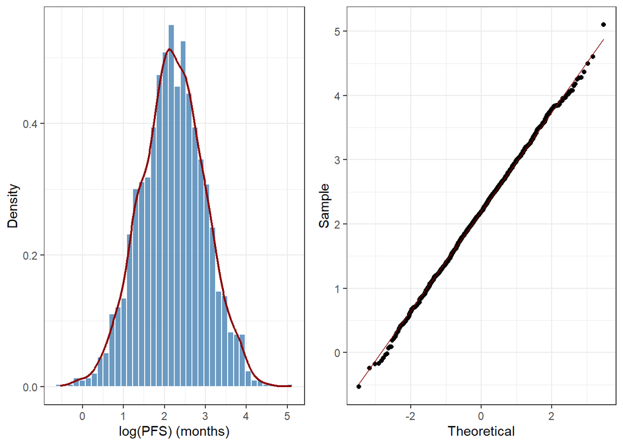

Figure A1. Distribution of log(PFS) and normal Q-Q plot (datA).

```r
p1 <- ggplot(datA, aes(x = log_PFS)) +
  geom_histogram(aes(y = after_stat(density)), bins = 40,
                 fill = "steelblue", color = "white", alpha = 0.8) +
  geom_density(color = "darkred", linewidth = 0.8) +
  labs(x = "log(PFS) (months)", y = "Density") +
  theme_bw()

p2 <- ggplot(datA, aes(sample = log_PFS)) +
  stat_qq() + stat_qq_line(color = "darkred") +

  labs(x = "Theoretical", y = "Sample") +
  theme_bw()

gridExtra::grid.arrange(p1, p2, ncol = 2)
```

### Summary Statistics

```r
datA |>
  select(all_of(cont_vars)) |>
  summarise(across(everything(), list(
    Mean   = \(x) round(mean(x), 2),
    SD     = \(x) round(sd(x), 2),
    Median = \(x) round(median(x), 2),
    Min    = \(x) round(min(x), 2),
    Max    = \(x) round(max(x), 2)
  ))) |>
  pivot_longer(everything(), names_to = c("Variable", "Stat"), names_sep = "_(?=[^_]+$)") |>
  pivot_wider(names_from = Stat, values_from = value) |>
  kable(caption = "Table 1. Summary statistics of continuous variables (datA).") |>
  kable_styling(bootstrap_options = c("striped", "condensed"), font_size = 10)
```

Table 1. Summary statistics of continuous variables (datA).

| Variable | Mean | SD | Median | Min | Max |
| --- | --- | --- | --- | --- | --- |
| age | 54.99 | 11.65 | 55.00 | 25.00 | 85.0 |
| bmi | 26.06 | 4.56 | 26.05 | 16.00 | 42.6 |
| tumor_size | 3.38 | 1.71 | 3.10 | 0.30 | 8.3 |
| lymph_nodes | 2.62 | 2.59 | 2.00 | 0.00 | 16.0 |
| Ki67 | 21.85 | 11.58 | 21.60 | 1.00 | 62.3 |
| log_PFS | 2.20 | 0.78 | 2.19 | -0.53 | 5.1 |

```r
datA |>
  select(all_of(cat_vars)) |>
  pivot_longer(everything(), names_to = "Variable", values_to = "Level") |>
  count(Variable, Level) |>
  group_by(Variable) |>
  mutate(`n (%)` = paste0(n, " (", round(100 * n / sum(n), 1), "%)")) |>
  select(-n) |>
  kable(caption = "Table 2. Frequency distribution of categorical variables (datA).") |>
  kable_styling(bootstrap_options = c("striped", "condensed"), font_size = 10)
```

Table 2. Frequency distribution of categorical variables (datA).

| Variable | Level | n (%) |
| --- | --- | --- |
| ER | Neg | 719 (36%) |
| ER | Pos | 1281 (64%) |
| HER2 | Neg | 1556 (77.8%) |
| HER2 | Pos | 444 (22.2%) |
| PR | Neg | 1039 (52%) |
| PR | Pos | 961 (48%) |
| chemo | No | 895 (44.8%) |
| chemo | Yes | 1105 (55.2%) |
| hormonal_therapy | No | 1066 (53.3%) |
| hormonal_therapy | Yes | 934 (46.7%) |
| menopause | Pre | 689 (34.5%) |
| menopause | Post | 1311 (65.6%) |
| race | White | 1284 (64.2%) |
| race | Black | 289 (14.4%) |
| race | Asian | 176 (8.8%) |
| race | Hispanic | 251 (12.6%) |
| stage | I | 504 (25.2%) |
| stage | II | 893 (44.6%) |
| stage | III | 603 (30.1%) |
| surgery | BCS | 986 (49.3%) |
| surgery | Mastectomy | 1014 (50.7%) |
| tumor_grade | Well | 383 (19.1%) |
| tumor_grade | Moderate | 871 (43.5%) |
| tumor_grade | Poor | 746 (37.3%) |

### Correlation Among Continuous Predictors

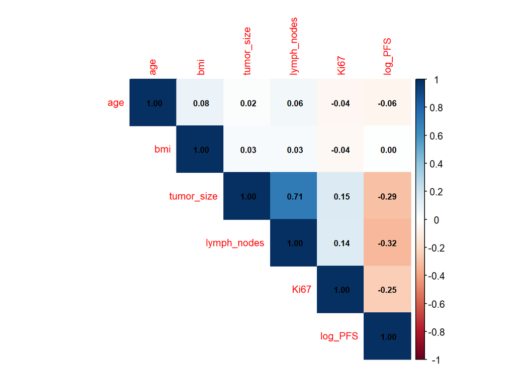

Figure A2. Correlation matrix of continuous predictors (datA).

```r
datA |>
  select(all_of(cont_vars)) |>
  cor() |>
  corrplot(method = "color", type = "upper",
           addCoef.col = "black", number.cex = 0.7, tl.cex = 0.8,
           mar = c(0, 0, 1, 0))
```

### Outcome by Predictors

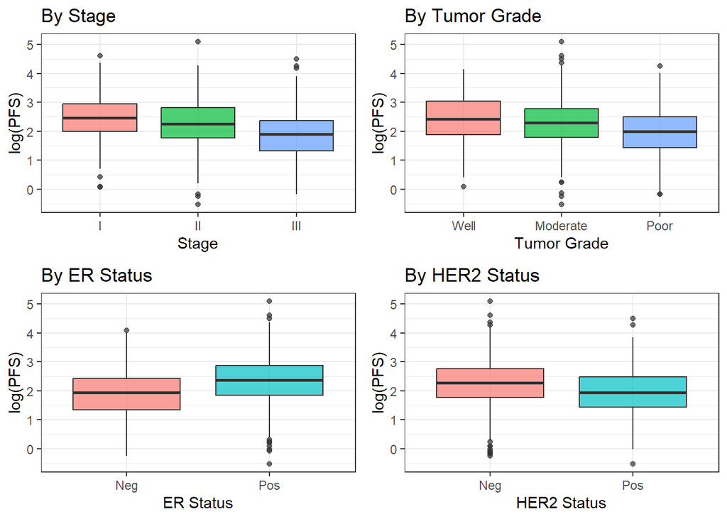

```r
p_stage <- ggplot(datA, aes(x = stage, y = log_PFS, fill = stage)) +
  geom_boxplot(alpha = 0.7, show.legend = FALSE) +
  labs(x = "Stage", y = "log(PFS)", title = "By Stage") + theme_bw()

p_grade <- ggplot(datA, aes(x = tumor_grade, y = log_PFS, fill = tumor_grade)) +
  geom_boxplot(alpha = 0.7, show.legend = FALSE) +
  labs(x = "Tumor Grade", y = "log(PFS)", title = "By Tumor Grade") + theme_bw()

p_er <- ggplot(datA, aes(x = ER, y = log_PFS, fill = ER)) +
  geom_boxplot(alpha = 0.7, show.legend = FALSE) +
  labs(x = "ER Status", y = "log(PFS)", title = "By ER Status") + theme_bw()

p_her2 <- ggplot(datA, aes(x = HER2, y = log_PFS, fill = HER2)) +
  geom_boxplot(alpha = 0.7, show.legend = FALSE) +
  labs(x = "HER2 Status", y = "log(PFS)", title = "By HER2 Status") + theme_bw()

gridExtra::grid.arrange(p_stage, p_grade, p_er, p_her2, ncol = 2)
```

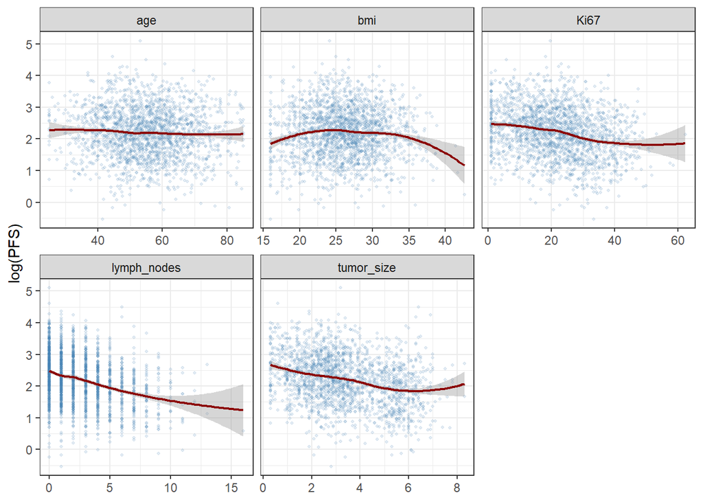

```r
datA |>
  select(log_PFS, age, bmi, tumor_size, lymph_nodes, Ki67) |>
  pivot_longer(-log_PFS, names_to = "Predictor", values_to = "Value") |>
  ggplot(aes(x = Value, y = log_PFS)) +
  geom_point(alpha = 0.15, size = 0.8, color = "steelblue") +
  geom_smooth(method = "loess", color = "darkred", se = TRUE, linewidth = 0.8) +
  facet_wrap(~Predictor, scales = "free_x", ncol = 3) +
  labs(x = NULL, y = "log(PFS)") +
  theme_bw()
```

### Summary

The outcome `log_PFS` is approximately normally distributed, supporting the use of linear regression-based models.

Among continuous predictors, `lymph_nodes` (r = −0.32), `tumor_size` (r = −0.29), and `Ki67` (r = −0.25) show the strongest marginal associations with `log_PFS`, while `age` and `bmi` show near-zero linear correlation. Critically, `tumor_size` and `lymph_nodes`are strongly collinear (r = 0.71), which inflates variance in OLS and motivates the use of **Elastic Net** regularization to stabilize coefficient estimates.

Together, these findings support training four candidate models: OLS (baseline), Elastic Net (collinearity), GAM (non-linearity), and MARS (non-linearity + interactions).

## Model Training

### Model 1: OLS Linear Regression

```r
set.seed(1)
fit_ols <- train(
  log_PFS ~ .,
  data      = datA,
  method    = "lm",
  trControl = ctrl,
  preProcess = c("center", "scale")
)

summary(fit_ols$finalModel)
```

```
##
## Call:
## lm(formula = .outcome ~ ., data = dat)
##
## Residuals:
##      Min       1Q   Median       3Q      Max
## -2.73137 -0.48208  0.01378  0.47165  2.68971
##
## Coefficients:
##                       Estimate Std. Error t value Pr(>|t|)
## (Intercept)          2.196e+00  1.567e-02 140.122  < 2e-16 ***
## age                 -4.675e-02  2.250e-02  -2.078 0.037874 *
## menopausePost        1.737e-02  2.246e-02   0.773 0.439351
## raceBlack            1.119e-02  1.611e-02   0.694 0.487530
## raceAsian            1.610e-02  1.603e-02   1.004 0.315293
## raceHispanic        -1.328e-02  1.610e-02  -0.825 0.409528
## bmi                  5.662e-03  1.586e-02   0.357 0.721157
## tumor_size          -1.135e-01  3.431e-02  -3.308 0.000957 ***
## tumor_gradeModerate -2.521e-02  2.320e-02  -1.087 0.277348
## tumor_gradePoor     -8.158e-02  2.893e-02  -2.820 0.004855 **
## lymph_nodes         -1.696e-01  2.540e-02  -6.677 3.17e-11 ***
## ERPos                1.149e-01  2.497e-02   4.599 4.51e-06 ***
## PRPos               -3.493e-03  1.953e-02  -0.179 0.858102
## HER2Pos             -7.069e-02  1.620e-02  -4.363 1.35e-05 ***
## Ki67                -4.168e-02  2.316e-02  -1.800 0.072070 .
## stageII              2.627e-02  2.603e-02   1.009 0.312963
## stageIII             5.045e-02  4.769e-02   1.058 0.290172
## surgeryMastectomy   -6.893e-03  1.674e-02  -0.412 0.680516
## chemoYes             6.173e-05  1.627e-02   0.004 0.996973
## hormonal_therapyYes  6.781e-02  2.002e-02   3.388 0.000718 ***
## ---
## Signif. codes:  0 '***' 0.001 '**' 0.01 '*' 0.05 '.' 0.1 ' ' 1
##
## Residual standard error: 0.7008 on 1980 degrees of freedom
## Multiple R-squared:  0.2071, Adjusted R-squared:  0.1994
## F-statistic: 27.21 on 19 and 1980 DF,  p-value: < 2.2e-16
```

### Model 2: Elastic Net

```r
set.seed(1)
enet_grid <- expand.grid(
  alpha  = seq(0, 1, by = 0.1),
  lambda = exp(seq(log(0.001), log(1), length.out = 50))
)

fit_enet <- train(
  log_PFS ~ .,
  data       = datA,
  method     = "glmnet",
  trControl  = ctrl,
  tuneGrid   = enet_grid,
  preProcess = c("center", "scale")
)

# Best tuning parameters
fit_enet$bestTune
```

|  | alpha | lambda |
| --- | --- | --- |
| 518 | 1 | 0.01098541 |

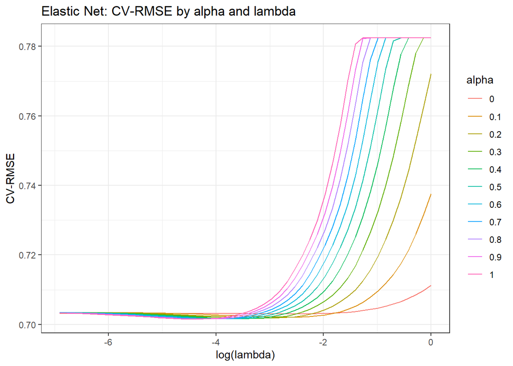

```r
# Plot CV-RMSE vs log(lambda), one line per alpha
fit_enet$results |>
  filter(!is.na(RMSE)) |>
  ggplot(aes(x = log(lambda), y = RMSE, color = factor(alpha), group = factor(alpha))) +
  geom_line() +
  labs(x = "log(lambda)", y = "CV-RMSE", color = "alpha",
       title = "Elastic Net: CV-RMSE by alpha and lambda") +
  theme_bw()
```

### Model 3: GAM

```r
set.seed(1)

# Final GAM on full datA
fit_gam <- mgcv::gam(
  log_PFS ~ s(age) + s(bmi) + s(tumor_size) + s(lymph_nodes) + s(Ki67) +
    menopause + race + tumor_grade + stage +
    ER + PR + HER2 + surgery + chemo + hormonal_therapy,
  data   = datA,
  method = "REML"
)

summary(fit_gam)
```

```
##
## Family: gaussian
## Link function: identity
##
## Formula:
## log_PFS ~ s(age) + s(bmi) + s(tumor_size) + s(lymph_nodes) +
##     s(Ki67) + menopause + race + tumor_grade + stage + ER + PR +
##     HER2 + surgery + chemo + hormonal_therapy
##
## Parametric coefficients:
##                      Estimate Std. Error t value Pr(>|t|)
## (Intercept)          2.012905   0.077485  25.978  < 2e-16 ***
## menopausePost        0.038094   0.046846   0.813 0.416211
## raceBlack            0.038229   0.045403   0.842 0.399890
## raceAsian            0.066824   0.056119   1.191 0.233896
## raceHispanic        -0.041785   0.048191  -0.867 0.386005
## tumor_gradeModerate -0.044954   0.046370  -0.969 0.332434
## tumor_gradePoor     -0.162251   0.059295  -2.736 0.006268 **
## stageII              0.084652   0.055560   1.524 0.127765
## stageIII             0.094919   0.104422   0.909 0.363465
## ERPos                0.233699   0.051576   4.531 6.22e-06 ***
## PRPos               -0.005595   0.038736  -0.144 0.885168
## HER2Pos             -0.173562   0.038658  -4.490 7.54e-06 ***
## surgeryMastectomy   -0.008269   0.033194  -0.249 0.803296
## chemoYes            -0.001415   0.032425  -0.044 0.965206
## hormonal_therapyYes  0.132521   0.039793   3.330 0.000884 ***
## ---
## Signif. codes:  0 '***' 0.001 '**' 0.01 '*' 0.05 '.' 0.1 ' ' 1
##
## Approximate significance of smooth terms:
##                  edf Ref.df      F  p-value
## s(age)         1.001  1.001  4.743  0.02949 *
## s(bmi)         3.995  4.988  7.074 2.09e-06 ***
## s(tumor_size)  2.121  2.729  4.552  0.00558 **
## s(lymph_nodes) 1.002  1.004 46.351  < 2e-16 ***
## s(Ki67)        1.001  1.002  3.828  0.05050 .
## ---
## Signif. codes:  0 '***' 0.001 '**' 0.01 '*' 0.05 '.' 0.1 ' ' 1
##
## R-sq.(adj) =  0.215   Deviance explained = 22.4%
## -REML = 2151.9  Scale est. = 0.48184   n = 2000
```

```r
folds <- createFolds(datA$log_PFS, k = 10, list = TRUE, returnTrain = FALSE)

gam_preds <- numeric(nrow(datA))
for (i in seq_along(folds)) {
  train_i <- datA[-folds[[i]], ]
  test_i  <- datA[ folds[[i]], ]
  gam_i   <- mgcv::gam(
    log_PFS ~ s(age) + s(bmi) + s(tumor_size) + s(lymph_nodes) + s(Ki67) +
      menopause + race + tumor_grade + stage +
      ER + PR + HER2 + surgery + chemo + hormonal_therapy,
    data = train_i, method = "REML"
  )
  gam_preds[folds[[i]]] <- predict(gam_i, newdata = test_i)
}

gam_cv_rmse <- sqrt(mean((datA$log_PFS - gam_preds)^2))
gam_cv_r2   <- cor(datA$log_PFS, gam_preds)^2
cat("GAM 10-fold CV RMSE:", round(gam_cv_rmse, 4),
    " R2:", round(gam_cv_r2, 4), "\n")
```

```
## GAM 10-fold CV RMSE: 0.6975  R2: 0.2068
```

### Model 4: MARS

```r
set.seed(1)
mars_grid <- expand.grid(
  degree = 1:2,
  nprune = 2:20
)

fit_mars <- train(
  log_PFS ~ .,
  data      = datA,
  method    = "earth",
  trControl = ctrl,
  tuneGrid  = mars_grid,
  preProcess = c("center", "scale")
)

fit_mars$bestTune
```

|  | nprune | degree |
| --- | --- | --- |
| 19 | 20 | 1 |

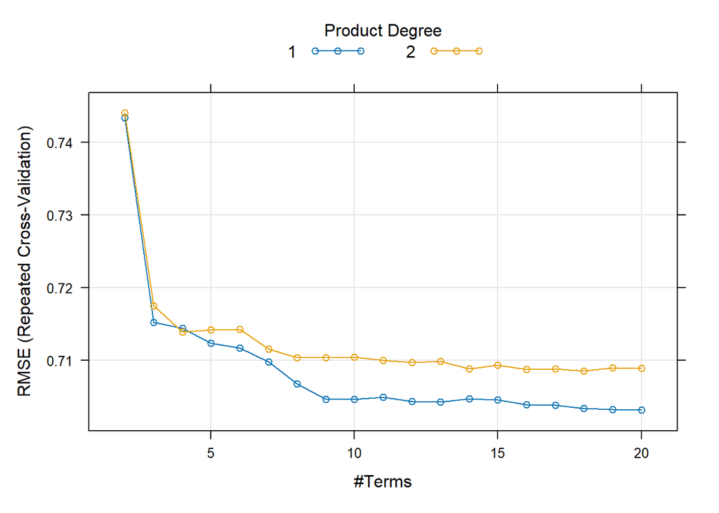

```r
plot(fit_mars)
```

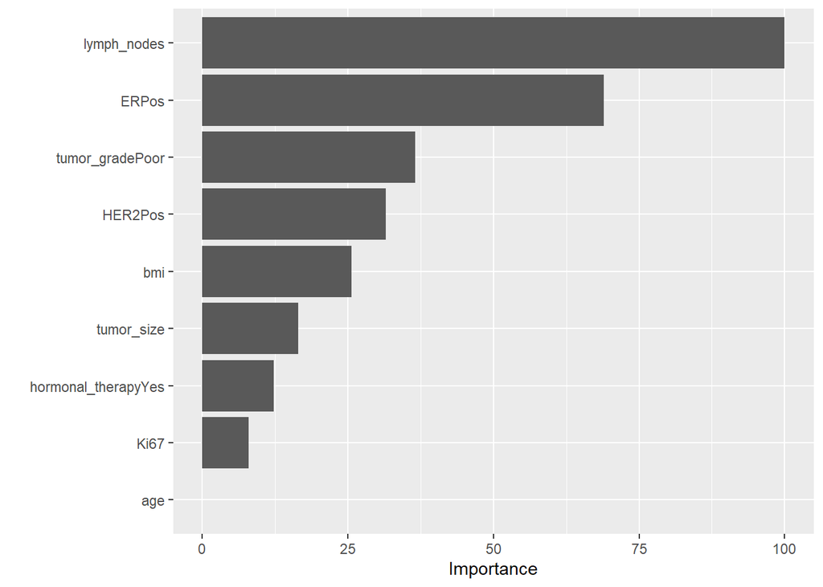

```r
# Variable importance
vip::vip(fit_mars, num_features = 15)
```

## Model Comparison & Selection

```r
# caret models compared via resamples()
resamples_list <- resamples(list(
  OLS        = fit_ols,
  ElasticNet = fit_enet,
  MARS       = fit_mars
))

cv_stats <- summary(resamples_list)$statistics

caret_rmse <- cv_stats$RMSE[, "Mean"]
caret_r2   <- cv_stats$Rsquared[, "Mean"]

# Add GAM
all_cv <- data.frame(
  Model   = c(names(caret_rmse), "GAM"),
  CV_RMSE = round(c(caret_rmse, gam_cv_rmse), 4),
  CV_R2   = round(c(caret_r2,   gam_cv_r2),   4)
) |> arrange(CV_RMSE)

all_cv |>
  kable(caption = "Table 3. Cross-validated RMSE and R-squared for four candidate models (datA).",
        col.names = c("Model", "CV-RMSE", "CV-R2")) |>
  kable_styling(bootstrap_options = c("striped", "condensed"), font_size = 10)
```

Table 3. Cross-validated RMSE and R-squared for four candidate models (datA).

|  | Model | CV-RMSE | CV-R2 |
| --- | --- | --- | --- |
| …1 | GAM | 0.6975 | 0.2068 |
| ElasticNet | ElasticNet | 0.7016 | 0.1996 |
| MARS | MARS | 0.7031 | 0.1979 |
| OLS | OLS | 0.7035 | 0.1951 |

### Final Model Selection

**Selected model: GAM**

```r
# GAM as final model
cat("Final model: GAM\n")
```

```
## Final model: GAM
```

```r
cat("CV-RMSE: ", round(gam_cv_rmse, 4), "\n")
```

```
## CV-RMSE:  0.6975
```

```r
cat("CV-R2:   ", round(gam_cv_r2,   4), "\n")
```

```
## CV-R2:    0.2068
```

The modest overall R-square (0.21) is consistent with clinical-only prediction models for PFS in the literature and reflects unmeasured biological factors (e.g., genomic profiles) rather than model misspecification.

## Final Model: Results & Interpretation

### Model Coefficients (Parametric Terms)

```r
# Extract parametric coefficients from GAM
gam_coef <- summary(fit_gam)$p.table |>
  as.data.frame() |>
  rownames_to_column("Term") |>
  mutate(across(where(is.numeric), \(x) round(x, 4))) |>
  rename(SE = `Std. Error`, `t-value` = `t value`, `p-value` = `Pr(>|t|)`)

gam_coef |>
  kable(caption = "Table 3a. GAM parametric coefficient estimates (datA).") |>
  kable_styling(bootstrap_options = c("striped", "condensed"), font_size = 10)
```

Table 3a. GAM parametric coefficient estimates (datA).

| Term | Estimate | SE | t-value | p-value |
| --- | --- | --- | --- | --- |
| (Intercept) | 2.0129 | 0.0775 | 25.9779 | 0.0000 |
| menopausePost | 0.0381 | 0.0468 | 0.8132 | 0.4162 |
| raceBlack | 0.0382 | 0.0454 | 0.8420 | 0.3999 |
| raceAsian | 0.0668 | 0.0561 | 1.1907 | 0.2339 |
| raceHispanic | -0.0418 | 0.0482 | -0.8671 | 0.3860 |
| tumor_gradeModerate | -0.0450 | 0.0464 | -0.9695 | 0.3324 |
| tumor_gradePoor | -0.1623 | 0.0593 | -2.7363 | 0.0063 |
| stageII | 0.0847 | 0.0556 | 1.5236 | 0.1278 |
| stageIII | 0.0949 | 0.1044 | 0.9090 | 0.3635 |
| ERPos | 0.2337 | 0.0516 | 4.5312 | 0.0000 |
| PRPos | -0.0056 | 0.0387 | -0.1444 | 0.8852 |
| HER2Pos | -0.1736 | 0.0387 | -4.4897 | 0.0000 |
| surgeryMastectomy | -0.0083 | 0.0332 | -0.2491 | 0.8033 |
| chemoYes | -0.0014 | 0.0324 | -0.0436 | 0.9652 |
| hormonal_therapyYes | 0.1325 | 0.0398 | 3.3303 | 0.0009 |

```r
# Smooth terms significance
gam_smooth <- summary(fit_gam)$s.table |>
  as.data.frame() |>
  rownames_to_column("Smooth Term") |>
  mutate(across(where(is.numeric), \(x) round(x, 3)))

gam_smooth |>
  kable(caption = "Table 3b. GAM smooth term significance (datA). edf > 1 indicates non-linearity.") |>
  kable_styling(bootstrap_options = c("striped", "condensed"), font_size = 10)
```

Table 3b. GAM smooth term significance (datA). edf > 1 indicates non-linearity.

| Smooth Term | edf | Ref.df | F | p-value |
| --- | --- | --- | --- | --- |
| s(age) | 1.001 | 1.001 | 4.743 | 0.029 |
| s(bmi) | 3.995 | 4.988 | 7.074 | 0.000 |
| s(tumor_size) | 2.121 | 2.729 | 4.552 | 0.006 |
| s(lymph_nodes) | 1.002 | 1.004 | 46.351 | 0.000 |
| s(Ki67) | 1.001 | 1.002 | 3.828 | 0.050 |

The following interpretation uses reference levels: White, pre-menopausal, Grade Well, Stage I, ER/PR/HER2-negative, BCS, no chemotherapy, no hormonal therapy.

**Demographic characteristics:** Age showed a small but significant negative smooth effect on log-PFS (p = 0.03), with older patients having slightly shorter PFS. BMI exhibited the strongest non-linearity, suggesting a non-monotonic relationship with PFS. Menopausal status and race were not significant after adjusting for other factors.

**Tumor characteristics:** Higher lymph node count was the strongest predictor of shorter PFS (p < 0.001). Larger tumor size was associated with worse PFS (p = 0.006). HER2-positive status was associated with 0.174 lower log-PFS compared to HER2-negative (p < 0.001), reflecting its aggressive phenotype in this pre-trastuzumab era cohort. ER-positive status was associated with 0.234 higher log-PFS (p < 0.001), consistent with the favorable prognosis of hormone receptor-positive tumors. Poorly differentiated tumors (Grade Poor) had significantly shorter PFS than well-differentiated tumors (est. = −0.162, p = 0.006). PR, Ki67, and stage were not significant after adjustment.

**Treatment characteristics:** Hormonal therapy was the only treatment variable significantly associated with PFS (est. = +0.133, p < 0.001), consistent with its established efficacy for ER-positive disease. Surgery type and chemotherapy receipt were not significant after adjusting for tumor and receptor characteristics.

### Partial Effect Plots (Smooth Terms)

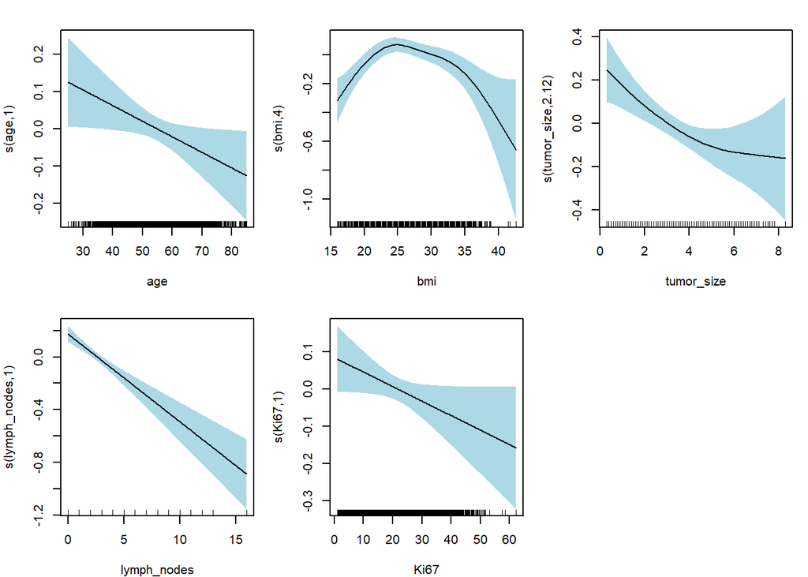

Figure A5. Partial effects of continuous predictors in the final GAM (datA). Shaded bands are 95% credible intervals; rug marks show data density.

```r
par(mfrow = c(2, 3), mar = c(4, 4, 2, 1))
plot(fit_gam, shade = TRUE, shade.col = "lightblue",
     seWithMean = TRUE, scale = 0)
par(mfrow = c(1, 1))
```

### Performance Assessment

```r
# Training RMSE and R2
train_pred  <- predict(fit_gam)
train_rmse  <- sqrt(mean((datA$log_PFS - train_pred)^2))
train_r2    <- summary(fit_gam)$r.sq

data.frame(
  Metric  = c("Training RMSE", "CV-RMSE (10-fold)", "Training R2 (adj)", "CV-R2"),
  Value   = round(c(train_rmse, gam_cv_rmse, train_r2, gam_cv_r2), 4)
) |>
  kable(caption = "Table 3c. GAM performance metrics (datA).") |>
  kable_styling(bootstrap_options = c("striped", "condensed"),
                full_width = FALSE, font_size = 10)
```

Table 3c. GAM performance metrics (datA).

| Metric | Value |
| --- | --- |
| Training RMSE | 0.6899 |
| CV-RMSE (10-fold) | 0.6975 |
| Training R2 (adj) | 0.2145 |
| CV-R2 | 0.2068 |

# Part II: Generalizability to datB (2000–2005)

## Cohort Comparison: datA vs datB

```r
load("datB.RData")

datB <- datB |>
  mutate(
    menopause        = factor(menopause, levels = c(0, 1), labels = c("Pre", "Post")),
    race             = factor(race, levels = c(1, 2, 3, 4),
                              labels = c("White", "Black", "Asian", "Hispanic")),
    tumor_grade      = factor(tumor_grade, levels = c(1, 2, 3),
                              labels = c("Well", "Moderate", "Poor")),
    stage            = factor(stage, levels = c(1, 2, 3), labels = c("I", "II", "III")),
    ER               = factor(ER,  levels = c(0, 1), labels = c("Neg", "Pos")),
    PR               = factor(PR,  levels = c(0, 1), labels = c("Neg", "Pos")),
    HER2             = factor(HER2, levels = c(0, 1), labels = c("Neg", "Pos")),
    surgery          = factor(surgery, levels = c(0, 1), labels = c("BCS", "Mastectomy")),
    chemo            = factor(chemo, levels = c(0, 1), labels = c("No", "Yes")),
    hormonal_therapy = factor(hormonal_therapy, levels = c(0, 1), labels = c("No", "Yes"))
  ) |>
  select(-any_of("id"))
```

```r
# Outcome comparison
rbind(
  datA |> summarise(Cohort="datA (1990-95)", Mean=round(mean(log_PFS),3),
                    SD=round(sd(log_PFS),3), Median=round(median(log_PFS),3)),
  datB |> summarise(Cohort="datB (2000-05)", Mean=round(mean(log_PFS),3),
                    SD=round(sd(log_PFS),3), Median=round(median(log_PFS),3))
) |>
  kable(caption = "Table 4. Comparison of log(PFS) between cohorts.") |>
  kable_styling(bootstrap_options = c("striped", "condensed"), font_size = 10)
```

Table 4. Comparison of log(PFS) between cohorts.

| Cohort | Mean | SD | Median |
| --- | --- | --- | --- |
| datA (1990-95) | 2.196 | 0.783 | 2.191 |
| datB (2000-05) | 2.742 | 0.738 | 2.744 |

```r
# t-test on outcome
t.test(datA$log_PFS, datB$log_PFS)
```

```
##
##  Welch Two Sample t-test
##
## data:  datA$log_PFS and datB$log_PFS
## t = -22.721, df = 3983.8, p-value < 2.2e-16
## alternative hypothesis: true difference in means is not equal to 0
## 95 percent confidence interval:
##  -0.5938392 -0.4994985
## sample estimates:
## mean of x mean of y
##  2.195733  2.742402
```

```r
# Continuous predictor comparison
cont_pred <- c("age", "bmi", "tumor_size", "lymph_nodes", "Ki67")

map_dfr(cont_pred, function(v) {
  tibble(
    Variable = v,
    `datA mean (SD)` = paste0(round(mean(datA[[v]]), 2),
                               " (", round(sd(datA[[v]]), 2), ")"),
    `datB mean (SD)` = paste0(round(mean(datB[[v]]), 2),
                               " (", round(sd(datB[[v]]), 2), ")"),
    `Diff (B-A)`     = round(mean(datB[[v]]) - mean(datA[[v]]), 2),
    `p-value`        = round(t.test(datA[[v]], datB[[v]])$p.value, 4)
  )
}) |>
  kable(caption = "Table 5. Continuous predictor comparison between cohorts.") |>
  kable_styling(bootstrap_options = c("striped", "condensed"), font_size = 10)
```

Table 5. Continuous predictor comparison between cohorts.

| Variable | datA mean (SD) | datB mean (SD) | Diff (B-A) | p-value |
| --- | --- | --- | --- | --- |
| age | 54.99 (11.65) | 56.05 (11.22) | 1.06 | 0.0035 |
| bmi | 26.06 (4.56) | 27.44 (5.05) | 1.38 | 0.0000 |
| tumor_size | 3.38 (1.71) | 3.08 (1.68) | -0.31 | 0.0000 |
| lymph_nodes | 2.62 (2.59) | 2.32 (2.53) | -0.31 | 0.0002 |
| Ki67 | 21.85 (11.58) | 20.37 (11.71) | -1.48 | 0.0001 |

```r
# Treatment and key categorical comparison
treat_vars <- c("stage", "chemo", "hormonal_therapy", "surgery")

map_dfr(treat_vars, function(v) {
  pA <- round(100 * prop.table(table(datA[[v]])), 1)
  pB <- round(100 * prop.table(table(datB[[v]])), 1)
  tibble(
    Variable = v,
    `datA (%)` = paste(names(pA), pA, sep = "=", collapse = ", "),
    `datB (%)` = paste(names(pB), pB, sep = "=", collapse = ", ")
  )
}) |>
  kable(caption = "Table 6. Treatment and stage distribution between cohorts.") |>
  kable_styling(bootstrap_options = c("striped", "condensed"), font_size = 10)
```

Table 6. Treatment and stage distribution between cohorts.

| Variable | datA (%) | datB (%) |
| --- | --- | --- |
| stage | I=25.2, II=44.6, III=30.1 | I=34.6, II=41.4, III=24 |
| chemo | No=44.8, Yes=55.2 | No=35.1, Yes=64.9 |
| hormonal_therapy | No=53.3, Yes=46.7 | No=43, Yes=57 |
| surgery | BCS=49.3, Mastectomy=50.7 | BCS=55.9, Mastectomy=44.1 |

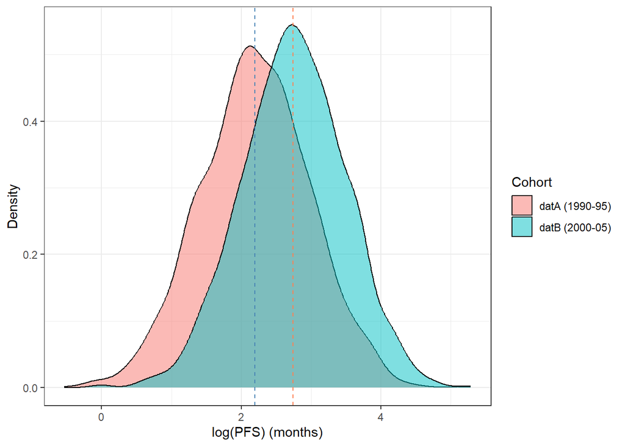

Figure A6. Distribution of log(PFS) in datA vs datB.

```r
bind_rows(
  datA |> select(log_PFS) |> mutate(Cohort = "datA (1990-95)"),
  datB |> select(log_PFS) |> mutate(Cohort = "datB (2000-05)")
) |>
  ggplot(aes(x = log_PFS, fill = Cohort)) +
  geom_density(alpha = 0.5) +
  geom_vline(xintercept = c(mean(datA$log_PFS), mean(datB$log_PFS)),
             linetype = "dashed", color = c("steelblue", "coral")) +
  labs(x = "log(PFS) (months)", y = "Density") +
  theme_bw()
```

# Prediction Model for Progression-Free Survival in Breast Cancer Patients

2026-03-27

# Setup

```r
library(tidyverse)
library(caret)
library(glmnet)
library(mgcv)        # GAM
library(earth)       # MARS
library(corrplot)
library(knitr)
library(kableExtra)
library(vip)         # variable importance
library(car)
```

```r
set.seed(1)

ctrl <- trainControl(
  method    = "repeatedcv",
  number    = 10,       # 10-fold
  repeats   = 5,        # 5 times
  savePredictions = TRUE
)
```

# Part I: Prediction Model for datA (1990–1995)

## Data Loading & Preprocessing

```r
load("datA.RData")

str(datA)
```

```
## 'data.frame':    2000 obs. of  17 variables:
##  $ id              : chr  "A0001" "A0002" "A0003" "A0004" ...
##  $ age             : num  61.2 42 56.7 54 47 25 46.2 42.8 56.4 49.3 ...
##  $ menopause       : int  1 0 1 1 0 0 0 0 1 1 ...
##  $ race            : int  1 1 1 1 3 1 1 3 1 1 ...
##  $ bmi             : num  31.8 24 34.4 18.7 22.2 27.1 28.9 27 28.8 29.5 ...
##  $ tumor_size      : num  4.8 4.3 4.5 5.1 2.2 4.8 1.5 3 2.7 1.7 ...
##  $ tumor_grade     : int  3 3 1 2 1 3 2 2 1 2 ...
##  $ lymph_nodes     : int  6 2 2 11 0 6 0 1 0 1 ...
##  $ ER              : int  1 1 1 1 0 0 1 1 0 1 ...
##  $ PR              : int  1 1 1 1 0 0 1 1 0 1 ...
##  $ HER2            : int  0 0 1 0 0 0 0 0 1 0 ...
##  $ Ki67            : num  27.6 22.7 5 15.6 23.1 45.9 17.5 27.1 24.7 16.4 ...
##  $ stage           : int  3 3 2 3 1 3 1 1 2 1 ...
##  $ surgery         : int  1 0 0 1 0 0 0 0 1 0 ...
##  $ chemo           : int  1 1 0 1 1 0 0 0 1 0 ...
##  $ hormonal_therapy: int  1 0 1 1 0 0 1 1 0 1 ...
##  $ log_PFS         : num  1.33 2.13 1.61 2.59 4.08 ...
```

```r
datA <- datA |>
  mutate(
    menopause       = factor(menopause, levels = c(0, 1),
                             labels = c("Pre", "Post")),
    race            = factor(race, levels = c(1, 2, 3, 4),
                             labels = c("White", "Black", "Asian", "Hispanic")),
    tumor_grade     = factor(tumor_grade, levels = c(1, 2, 3),
                             labels = c("Well", "Moderate", "Poor")),
    stage           = factor(stage, levels = c(1, 2, 3),
                             labels = c("I", "II", "III")),
    ER              = factor(ER,  levels = c(0, 1), labels = c("Neg", "Pos")),
    PR              = factor(PR,  levels = c(0, 1), labels = c("Neg", "Pos")),
    HER2            = factor(HER2, levels = c(0, 1), labels = c("Neg", "Pos")),
    surgery         = factor(surgery, levels = c(0, 1),
                             labels = c("BCS", "Mastectomy")),
    chemo           = factor(chemo, levels = c(0, 1), labels = c("No", "Yes")),
    hormonal_therapy = factor(hormonal_therapy, levels = c(0, 1),
                              labels = c("No", "Yes"))
  ) |>
  select(-any_of("id"))   # remove patient ID

# Reference levels: White, Grade Well, Stage I, Neg, BCS, No chemo, No hormonal
# (these are already the first levels set above)

dim(datA)
```

```
## [1] 2000   16
```

## Exploratory Data Analysis

```r
cont_vars <- c("age", "bmi", "tumor_size", "lymph_nodes", "Ki67", "log_PFS")
cat_vars  <- c("menopause", "race", "tumor_grade", "stage",
               "ER", "PR", "HER2", "surgery", "chemo", "hormonal_therapy")
```

### Outcome Distribution

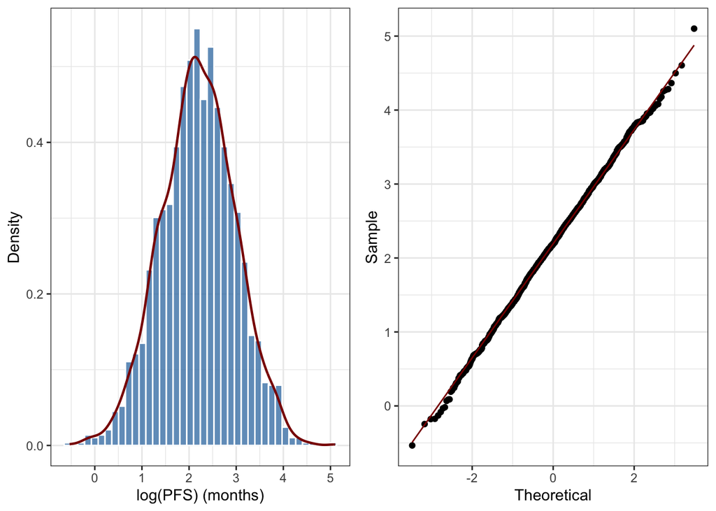

Figure A1. Distribution of log(PFS) and normal Q-Q plot (datA).

```r
p1 <- ggplot(datA, aes(x = log_PFS)) +
  geom_histogram(aes(y = after_stat(density)), bins = 40,
                 fill = "steelblue", color = "white", alpha = 0.8) +
  geom_density(color = "darkred", linewidth = 0.8) +
  labs(x = "log(PFS) (months)", y = "Density") +
  theme_bw()

p2 <- ggplot(datA, aes(sample = log_PFS)) +
  stat_qq() + stat_qq_line(color = "darkred") +

  labs(x = "Theoretical", y = "Sample") +
  theme_bw()

gridExtra::grid.arrange(p1, p2, ncol = 2)
```

### Summary Statistics

```r
datA |>
  select(all_of(cont_vars)) |>
  summarise(across(everything(), list(
    Mean   = \(x) round(mean(x), 2),
    SD     = \(x) round(sd(x), 2),
    Median = \(x) round(median(x), 2),
    Min    = \(x) round(min(x), 2),
    Max    = \(x) round(max(x), 2)
  ))) |>
  pivot_longer(everything(), names_to = c("Variable", "Stat"), names_sep = "_(?=[^_]+$)") |>
  pivot_wider(names_from = Stat, values_from = value) |>
  kable(caption = "Table 1. Summary statistics of continuous variables (datA).") |>
  kable_styling(bootstrap_options = c("striped", "condensed"), font_size = 10)
```

Table 1. Summary statistics of continuous variables (datA).

| Variable | Mean | SD | Median | Min | Max |
| --- | --- | --- | --- | --- | --- |
| age | 54.99 | 11.65 | 55.00 | 25.00 | 85.0 |
| bmi | 26.06 | 4.56 | 26.05 | 16.00 | 42.6 |
| tumor_size | 3.38 | 1.71 | 3.10 | 0.30 | 8.3 |
| lymph_nodes | 2.62 | 2.59 | 2.00 | 0.00 | 16.0 |
| Ki67 | 21.85 | 11.58 | 21.60 | 1.00 | 62.3 |
| log_PFS | 2.20 | 0.78 | 2.19 | -0.53 | 5.1 |

```r
datA |>
  select(all_of(cat_vars)) |>
  pivot_longer(everything(), names_to = "Variable", values_to = "Level") |>
  count(Variable, Level) |>
  group_by(Variable) |>
  mutate(`n (%)` = paste0(n, " (", round(100 * n / sum(n), 1), "%)")) |>
  select(-n) |>
  kable(caption = "Table 2. Frequency distribution of categorical variables (datA).") |>
  kable_styling(bootstrap_options = c("striped", "condensed"), font_size = 10)
```

Table 2. Frequency distribution of categorical variables (datA).

| Variable | Level | n (%) |
| --- | --- | --- |
| ER | Neg | 719 (36%) |
| ER | Pos | 1281 (64%) |
| HER2 | Neg | 1556 (77.8%) |
| HER2 | Pos | 444 (22.2%) |
| PR | Neg | 1039 (52%) |
| PR | Pos | 961 (48%) |
| chemo | No | 895 (44.8%) |
| chemo | Yes | 1105 (55.2%) |
| hormonal_therapy | No | 1066 (53.3%) |
| hormonal_therapy | Yes | 934 (46.7%) |
| menopause | Pre | 689 (34.5%) |
| menopause | Post | 1311 (65.6%) |
| race | White | 1284 (64.2%) |
| race | Black | 289 (14.4%) |
| race | Asian | 176 (8.8%) |
| race | Hispanic | 251 (12.6%) |
| stage | I | 504 (25.2%) |
| stage | II | 893 (44.6%) |
| stage | III | 603 (30.1%) |
| surgery | BCS | 986 (49.3%) |
| surgery | Mastectomy | 1014 (50.7%) |
| tumor_grade | Well | 383 (19.1%) |
| tumor_grade | Moderate | 871 (43.5%) |
| tumor_grade | Poor | 746 (37.3%) |

### Correlation Among Continuous Predictors

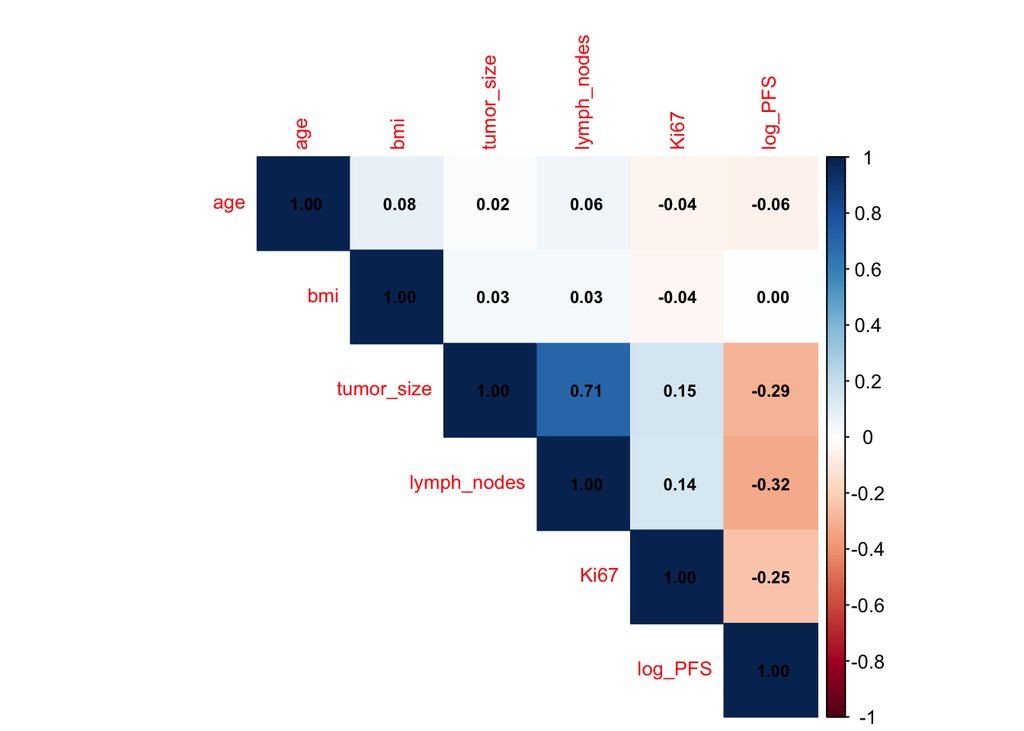

Figure A2. Correlation matrix of continuous predictors (datA).

```r
datA |>
  select(all_of(cont_vars)) |>
  cor() |>
  corrplot(method = "color", type = "upper",
           addCoef.col = "black", number.cex = 0.7, tl.cex = 0.8,
           mar = c(0, 0, 1, 0))
```

### Outcome by Predictors

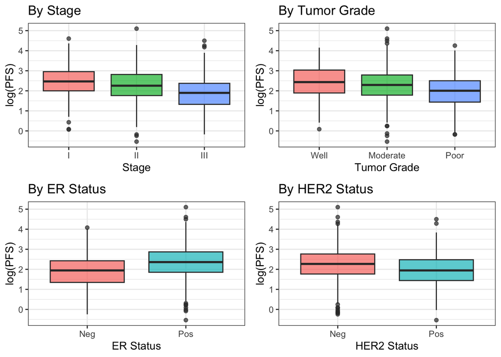

```r
p_stage <- ggplot(datA, aes(x = stage, y = log_PFS, fill = stage)) +
  geom_boxplot(alpha = 0.7, show.legend = FALSE) +
  labs(x = "Stage", y = "log(PFS)", title = "By Stage") + theme_bw()

p_grade <- ggplot(datA, aes(x = tumor_grade, y = log_PFS, fill = tumor_grade)) +
  geom_boxplot(alpha = 0.7, show.legend = FALSE) +
  labs(x = "Tumor Grade", y = "log(PFS)", title = "By Tumor Grade") + theme_bw()

p_er <- ggplot(datA, aes(x = ER, y = log_PFS, fill = ER)) +
  geom_boxplot(alpha = 0.7, show.legend = FALSE) +
  labs(x = "ER Status", y = "log(PFS)", title = "By ER Status") + theme_bw()

p_her2 <- ggplot(datA, aes(x = HER2, y = log_PFS, fill = HER2)) +
  geom_boxplot(alpha = 0.7, show.legend = FALSE) +
  labs(x = "HER2 Status", y = "log(PFS)", title = "By HER2 Status") + theme_bw()

gridExtra::grid.arrange(p_stage, p_grade, p_er, p_her2, ncol = 2)
```

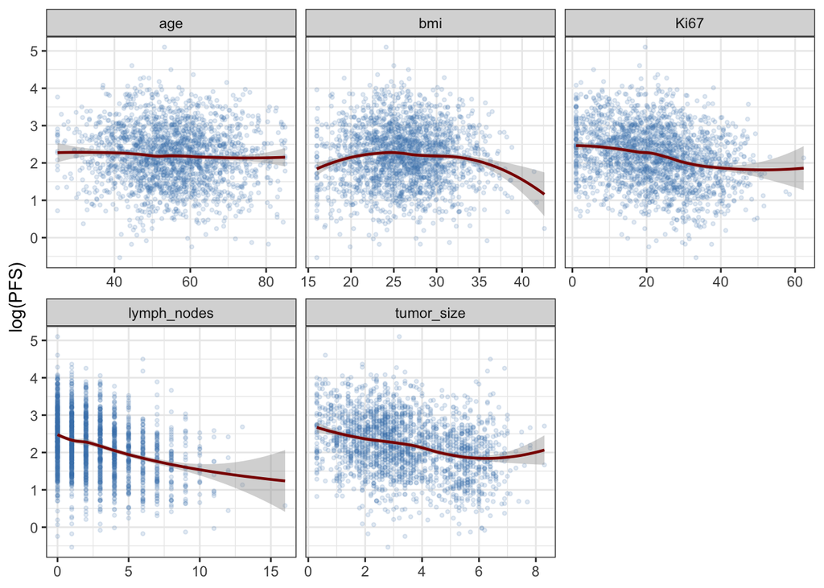

```r
datA |>
  select(log_PFS, age, bmi, tumor_size, lymph_nodes, Ki67) |>
  pivot_longer(-log_PFS, names_to = "Predictor", values_to = "Value") |>
  ggplot(aes(x = Value, y = log_PFS)) +
  geom_point(alpha = 0.15, size = 0.8, color = "steelblue") +
  geom_smooth(method = "loess", color = "darkred", se = TRUE, linewidth = 0.8) +
  facet_wrap(~Predictor, scales = "free_x", ncol = 3) +
  labs(x = NULL, y = "log(PFS)") +
  theme_bw()
```

### Summary

The outcome `log_PFS` is approximately normally distributed, supporting the use of linear regression-based models.

Among continuous predictors, `lymph_nodes` (r = −0.32), `tumor_size` (r = −0.29), and `Ki67` (r = −0.25) show the strongest marginal associations with `log_PFS`, while `age` and `bmi` show near-zero linear correlation. Critically, `tumor_size` and `lymph_nodes`are strongly collinear (r = 0.71), which inflates variance in OLS and motivates the use of **Elastic Net** regularization to stabilize coefficient estimates.

Together, these findings support training four candidate models: OLS (baseline), Elastic Net (collinearity), GAM (non-linearity), and MARS (non-linearity + interactions).

## Model Training

### Model 1: OLS Linear Regression

```r
set.seed(1)
fit_ols <- train(
  log_PFS ~ .,
  data      = datA,
  method    = "lm",
  trControl = ctrl,
  preProcess = c("center", "scale")
)

summary(fit_ols$finalModel)
```

```
##
## Call:
## lm(formula = .outcome ~ ., data = dat)
##
## Residuals:
##      Min       1Q   Median       3Q      Max
## -2.73137 -0.48208  0.01378  0.47165  2.68971
##
## Coefficients:
##                       Estimate Std. Error t value Pr(>|t|)
## (Intercept)          2.196e+00  1.567e-02 140.122  < 2e-16 ***
## age                 -4.675e-02  2.250e-02  -2.078 0.037874 *
## menopausePost        1.737e-02  2.246e-02   0.773 0.439351
## raceBlack            1.119e-02  1.611e-02   0.694 0.487530
## raceAsian            1.610e-02  1.603e-02   1.004 0.315293
## raceHispanic        -1.328e-02  1.610e-02  -0.825 0.409528
## bmi                  5.662e-03  1.586e-02   0.357 0.721157
## tumor_size          -1.135e-01  3.431e-02  -3.308 0.000957 ***
## tumor_gradeModerate -2.521e-02  2.320e-02  -1.087 0.277348
## tumor_gradePoor     -8.158e-02  2.893e-02  -2.820 0.004855 **
## lymph_nodes         -1.696e-01  2.540e-02  -6.677 3.17e-11 ***
## ERPos                1.149e-01  2.497e-02   4.599 4.51e-06 ***
## PRPos               -3.493e-03  1.953e-02  -0.179 0.858102
## HER2Pos             -7.069e-02  1.620e-02  -4.363 1.35e-05 ***
## Ki67                -4.168e-02  2.316e-02  -1.800 0.072070 .
## stageII              2.627e-02  2.603e-02   1.009 0.312963
## stageIII             5.045e-02  4.769e-02   1.058 0.290172
## surgeryMastectomy   -6.893e-03  1.674e-02  -0.412 0.680516
## chemoYes             6.173e-05  1.627e-02   0.004 0.996973
## hormonal_therapyYes  6.781e-02  2.002e-02   3.388 0.000718 ***
## ---
## Signif. codes:  0 '***' 0.001 '**' 0.01 '*' 0.05 '.' 0.1 ' ' 1
##
## Residual standard error: 0.7008 on 1980 degrees of freedom
## Multiple R-squared:  0.2071, Adjusted R-squared:  0.1994
## F-statistic: 27.21 on 19 and 1980 DF,  p-value: < 2.2e-16
```

### Model 2: Elastic Net

```r
set.seed(1)
enet_grid <- expand.grid(
  alpha  = seq(0, 1, by = 0.1),
  lambda = exp(seq(log(0.001), log(1), length.out = 50))
)

fit_enet <- train(
  log_PFS ~ .,
  data       = datA,
  method     = "glmnet",
  trControl  = ctrl,
  tuneGrid   = enet_grid,
  preProcess = c("center", "scale")
)

# Best tuning parameters
fit_enet$bestTune
```

|  | alpha | lambda |
| --- | --- | --- |
| 518 | 1 | 0.01098541 |

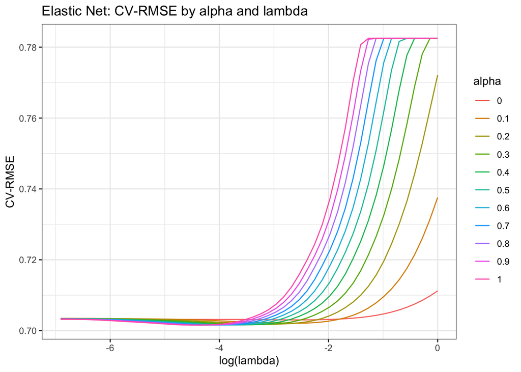

```r
# Plot CV-RMSE vs log(lambda), one line per alpha
fit_enet$results |>
  filter(!is.na(RMSE)) |>
  ggplot(aes(x = log(lambda), y = RMSE, color = factor(alpha), group = factor(alpha))) +
  geom_line() +
  labs(x = "log(lambda)", y = "CV-RMSE", color = "alpha",
       title = "Elastic Net: CV-RMSE by alpha and lambda") +
  theme_bw()
```

### Model 3: GAM

```r
set.seed(1)

# Final GAM on full datA
fit_gam <- mgcv::gam(
  log_PFS ~ s(age) + s(bmi) + s(tumor_size) + s(lymph_nodes) + s(Ki67) +
    menopause + race + tumor_grade + stage +
    ER + PR + HER2 + surgery + chemo + hormonal_therapy,
  data   = datA,
  method = "REML"
)

summary(fit_gam)
```

```
##
## Family: gaussian
## Link function: identity
##
## Formula:
## log_PFS ~ s(age) + s(bmi) + s(tumor_size) + s(lymph_nodes) +
##     s(Ki67) + menopause + race + tumor_grade + stage + ER + PR +
##     HER2 + surgery + chemo + hormonal_therapy
##
## Parametric coefficients:
##                      Estimate Std. Error t value Pr(>|t|)
## (Intercept)          2.012905   0.077485  25.978  < 2e-16 ***
## menopausePost        0.038094   0.046846   0.813 0.416211
## raceBlack            0.038229   0.045403   0.842 0.399890
## raceAsian            0.066824   0.056119   1.191 0.233896
## raceHispanic        -0.041785   0.048191  -0.867 0.386005
## tumor_gradeModerate -0.044954   0.046370  -0.969 0.332434
## tumor_gradePoor     -0.162251   0.059295  -2.736 0.006268 **
## stageII              0.084652   0.055560   1.524 0.127765
## stageIII             0.094919   0.104422   0.909 0.363465
## ERPos                0.233699   0.051576   4.531 6.22e-06 ***
## PRPos               -0.005595   0.038736  -0.144 0.885168
## HER2Pos             -0.173562   0.038658  -4.490 7.54e-06 ***
## surgeryMastectomy   -0.008269   0.033194  -0.249 0.803296
## chemoYes            -0.001415   0.032425  -0.044 0.965206
## hormonal_therapyYes  0.132521   0.039793   3.330 0.000884 ***
## ---
## Signif. codes:  0 '***' 0.001 '**' 0.01 '*' 0.05 '.' 0.1 ' ' 1
##
## Approximate significance of smooth terms:
##                  edf Ref.df      F  p-value
## s(age)         1.001  1.001  4.743  0.02949 *
## s(bmi)         3.995  4.988  7.074 2.09e-06 ***
## s(tumor_size)  2.121  2.729  4.552  0.00558 **
## s(lymph_nodes) 1.002  1.004 46.351  < 2e-16 ***
## s(Ki67)        1.001  1.002  3.828  0.05050 .
## ---
## Signif. codes:  0 '***' 0.001 '**' 0.01 '*' 0.05 '.' 0.1 ' ' 1
##
## R-sq.(adj) =  0.215   Deviance explained = 22.4%
## -REML = 2151.9  Scale est. = 0.48184   n = 2000
```

```r
folds <- createFolds(datA$log_PFS, k = 10, list = TRUE, returnTrain = FALSE)

gam_preds <- numeric(nrow(datA))
for (i in seq_along(folds)) {
  train_i <- datA[-folds[[i]], ]
  test_i  <- datA[ folds[[i]], ]
  gam_i   <- mgcv::gam(
    log_PFS ~ s(age) + s(bmi) + s(tumor_size) + s(lymph_nodes) + s(Ki67) +
      menopause + race + tumor_grade + stage +
      ER + PR + HER2 + surgery + chemo + hormonal_therapy,
    data = train_i, method = "REML"
  )
  gam_preds[folds[[i]]] <- predict(gam_i, newdata = test_i)
}

gam_cv_rmse <- sqrt(mean((datA$log_PFS - gam_preds)^2))
gam_cv_r2   <- cor(datA$log_PFS, gam_preds)^2
cat("GAM 10-fold CV RMSE:", round(gam_cv_rmse, 4),
    " R2:", round(gam_cv_r2, 4), "\n")
```

```
## GAM 10-fold CV RMSE: 0.6975  R2: 0.2068
```

### Model 4: MARS

```r
set.seed(1)
mars_grid <- expand.grid(
  degree = 1:2,
  nprune = 2:20
)

fit_mars <- train(
  log_PFS ~ .,
  data      = datA,
  method    = "earth",
  trControl = ctrl,
  tuneGrid  = mars_grid,
  preProcess = c("center", "scale")
)

fit_mars$bestTune
```

|  | nprune | degree |
| --- | --- | --- |
| 19 | 20 | 1 |

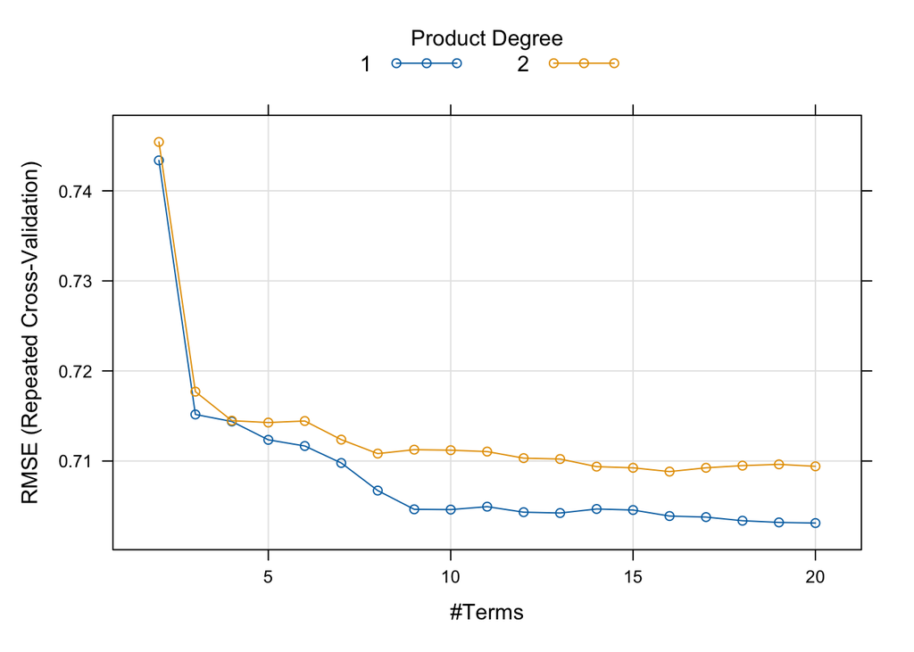

```r
plot(fit_mars)
```

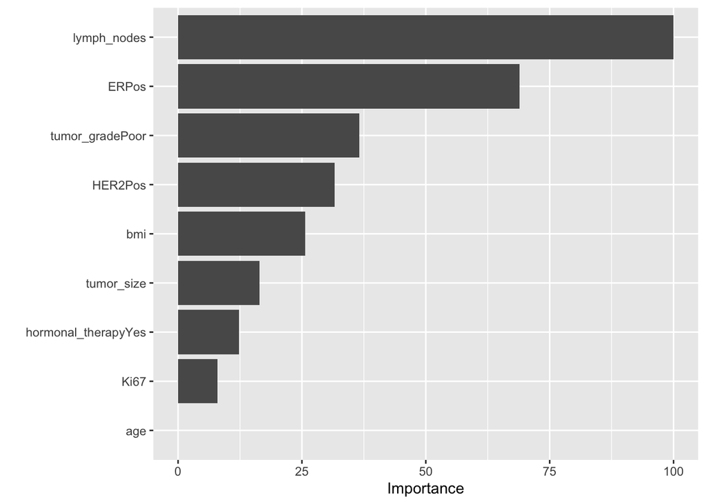

```r
# Variable importance
vip::vip(fit_mars, num_features = 15)
```

## Model Comparison & Selection

```r
# caret models compared via resamples()
resamples_list <- resamples(list(
  OLS        = fit_ols,
  ElasticNet = fit_enet,
  MARS       = fit_mars
))

cv_stats <- summary(resamples_list)$statistics

caret_rmse <- cv_stats$RMSE[, "Mean"]
caret_r2   <- cv_stats$Rsquared[, "Mean"]

# Add GAM
all_cv <- data.frame(
  Model   = c(names(caret_rmse), "GAM"),
  CV_RMSE = round(c(caret_rmse, gam_cv_rmse), 4),
  CV_R2   = round(c(caret_r2,   gam_cv_r2),   4)
) |> arrange(CV_RMSE)

all_cv |>
  kable(caption = "Table 3. Cross-validated RMSE and R-squared for four candidate models (datA).",
        col.names = c("Model", "CV-RMSE", "CV-R2")) |>
  kable_styling(bootstrap_options = c("striped", "condensed"), font_size = 10)
```

Table 3. Cross-validated RMSE and R-squared for four candidate models (datA).

|  | Model | CV-RMSE | CV-R2 |
| --- | --- | --- | --- |
| …1 | GAM | 0.6975 | 0.2068 |
| ElasticNet | ElasticNet | 0.7016 | 0.1996 |
| MARS | MARS | 0.7031 | 0.1979 |
| OLS | OLS | 0.7035 | 0.1951 |

### Final Model Selection

**Selected model: GAM**

```r
# GAM as final model
cat("Final model: GAM\n")
```

```
## Final model: GAM
```

```r
cat("CV-RMSE: ", round(gam_cv_rmse, 4), "\n")
```

```
## CV-RMSE:  0.6975
```

```r
cat("CV-R2:   ", round(gam_cv_r2,   4), "\n")
```

```
## CV-R2:    0.2068
```

GAM was selected as the final model for the following reasons:

- **Best predictive performance**: GAM achieved the lowest CV-RMSE
- **Empirically justified non-linearity**: EDA identified non-linear LOESS patterns for `bmi`, `tumor_size`, and `lymph_nodes`, validating the use of smooth terms over a purely linear specification.
- **Interactions not supported by data**: MARS with degree = 2 searched the full predictor space for useful two-way interactions and selected degree = 1, indicating no interaction term improved out-of-sample performance, supports an additive model structure.

The modest overall R-square (0.21) is consistent with clinical-only prediction models for PFS in the literature and reflects unmeasured biological factors (e.g., genomic profiles) rather than model misspecification.

## Final Model: Results & Interpretation

### Model Coefficients (Parametric Terms)

```r
# Extract parametric coefficients from GAM
gam_coef <- summary(fit_gam)$p.table |>
  as.data.frame() |>
  rownames_to_column("Term") |>
  mutate(across(where(is.numeric), \(x) round(x, 4))) |>
  rename(SE = `Std. Error`, `t-value` = `t value`, `p-value` = `Pr(>|t|)`)

gam_coef |>
  kable(caption = "Table 3a. GAM parametric coefficient estimates (datA).") |>
  kable_styling(bootstrap_options = c("striped", "condensed"), font_size = 10)
```

Table 3a. GAM parametric coefficient estimates (datA).

| Term | Estimate | SE | t-value | p-value |
| --- | --- | --- | --- | --- |
| (Intercept) | 2.0129 | 0.0775 | 25.9779 | 0.0000 |
| menopausePost | 0.0381 | 0.0468 | 0.8132 | 0.4162 |
| raceBlack | 0.0382 | 0.0454 | 0.8420 | 0.3999 |
| raceAsian | 0.0668 | 0.0561 | 1.1907 | 0.2339 |
| raceHispanic | -0.0418 | 0.0482 | -0.8671 | 0.3860 |
| tumor_gradeModerate | -0.0450 | 0.0464 | -0.9695 | 0.3324 |
| tumor_gradePoor | -0.1623 | 0.0593 | -2.7363 | 0.0063 |
| stageII | 0.0847 | 0.0556 | 1.5236 | 0.1278 |
| stageIII | 0.0949 | 0.1044 | 0.9090 | 0.3635 |
| ERPos | 0.2337 | 0.0516 | 4.5312 | 0.0000 |
| PRPos | -0.0056 | 0.0387 | -0.1444 | 0.8852 |
| HER2Pos | -0.1736 | 0.0387 | -4.4897 | 0.0000 |
| surgeryMastectomy | -0.0083 | 0.0332 | -0.2491 | 0.8033 |
| chemoYes | -0.0014 | 0.0324 | -0.0436 | 0.9652 |
| hormonal_therapyYes | 0.1325 | 0.0398 | 3.3303 | 0.0009 |

```r
# Smooth terms significance
gam_smooth <- summary(fit_gam)$s.table |>
  as.data.frame() |>
  rownames_to_column("Smooth Term") |>
  mutate(across(where(is.numeric), \(x) round(x, 3)))

gam_smooth |>
  kable(caption = "Table 3b. GAM smooth term significance (datA). edf > 1 indicates non-linearity.") |>
  kable_styling(bootstrap_options = c("striped", "condensed"), font_size = 10)
```

Table 3b. GAM smooth term significance (datA). edf > 1 indicates non-linearity.

| Smooth Term | edf | Ref.df | F | p-value |
| --- | --- | --- | --- | --- |
| s(age) | 1.001 | 1.001 | 4.743 | 0.029 |
| s(bmi) | 3.995 | 4.988 | 7.074 | 0.000 |
| s(tumor_size) | 2.121 | 2.729 | 4.552 | 0.006 |
| s(lymph_nodes) | 1.002 | 1.004 | 46.351 | 0.000 |
| s(Ki67) | 1.001 | 1.002 | 3.828 | 0.050 |

The following interpretation uses reference levels: White, pre-menopausal, Grade Well, Stage I, ER/PR/HER2-negative, BCS, no chemotherapy, no hormonal therapy.

**Demographic characteristics:** Age showed a small but significant negative smooth effect on log-PFS (p = 0.03), with older patients having slightly shorter PFS. BMI exhibited the strongest non-linearity, suggesting a non-monotonic relationship with PFS. Menopausal status and race were not significant after adjusting for other factors.

**Tumor characteristics:** Higher lymph node count was the strongest predictor of shorter PFS (p < 0.001). Larger tumor size was associated with worse PFS (p = 0.006). HER2-positive status was associated with 0.174 lower log-PFS compared to HER2-negative (p < 0.001), reflecting its aggressive phenotype in this pre-trastuzumab era cohort. ER-positive status was associated with 0.234 higher log-PFS (p < 0.001), consistent with the favorable prognosis of hormone receptor-positive tumors. Poorly differentiated tumors (Grade Poor) had significantly shorter PFS than well-differentiated tumors (est. = −0.162, p = 0.006). PR, Ki67, and stage were not significant after adjustment.

**Treatment characteristics:** Hormonal therapy was the only treatment variable significantly associated with PFS (est. = +0.133, p < 0.001), consistent with its established efficacy for ER-positive disease. Surgery type and chemotherapy receipt were not significant after adjusting for tumor and receptor characteristics.

### Partial Effect Plots (Smooth Terms)

[figure not shown]

```r
par(mfrow = c(2, 3), mar = c(4, 4, 2, 1))
plot(fit_gam, shade = TRUE, shade.col = "lightblue",
     seWithMean = TRUE, scale = 0)
par(mfrow = c(1, 1))
```

### Performance Assessment

```r
# Training RMSE and R2
train_pred  <- predict(fit_gam)
train_rmse  <- sqrt(mean((datA$log_PFS - train_pred)^2))
train_r2    <- summary(fit_gam)$r.sq

data.frame(
  Metric  = c("Training RMSE", "CV-RMSE (10-fold)", "Training R2 (adj)", "CV-R2"),
  Value   = round(c(train_rmse, gam_cv_rmse, train_r2, gam_cv_r2), 4)
) |>
  kable(caption = "Table 3c. GAM performance metrics (datA).") |>
  kable_styling(bootstrap_options = c("striped", "condensed"),
                full_width = FALSE, font_size = 10)
```

Table 3c. GAM performance metrics (datA).

| Metric | Value |
| --- | --- |
| Training RMSE | 0.6899 |
| CV-RMSE (10-fold) | 0.6975 |
| Training R2 (adj) | 0.2145 |
| CV-R2 | 0.2068 |

# Part II: Generalizability to datB (2000–2005)

## Cohort Comparison: datA vs datB

```r
load("datB.RData")

datB <- datB |>
  mutate(
    menopause        = factor(menopause, levels = c(0, 1), labels = c("Pre", "Post")),
    race             = factor(race, levels = c(1, 2, 3, 4),
                              labels = c("White", "Black", "Asian", "Hispanic")),
    tumor_grade      = factor(tumor_grade, levels = c(1, 2, 3),
                              labels = c("Well", "Moderate", "Poor")),
    stage            = factor(stage, levels = c(1, 2, 3), labels = c("I", "II", "III")),
    ER               = factor(ER,  levels = c(0, 1), labels = c("Neg", "Pos")),
    PR               = factor(PR,  levels = c(0, 1), labels = c("Neg", "Pos")),
    HER2             = factor(HER2, levels = c(0, 1), labels = c("Neg", "Pos")),
    surgery          = factor(surgery, levels = c(0, 1), labels = c("BCS", "Mastectomy")),
    chemo            = factor(chemo, levels = c(0, 1), labels = c("No", "Yes")),
    hormonal_therapy = factor(hormonal_therapy, levels = c(0, 1), labels = c("No", "Yes"))
  ) |>
  select(-any_of("id"))
```

```r
# Outcome comparison
rbind(
  datA |> summarise(Cohort="datA (1990-95)", Mean=round(mean(log_PFS),3),
                    SD=round(sd(log_PFS),3), Median=round(median(log_PFS),3)),
  datB |> summarise(Cohort="datB (2000-05)", Mean=round(mean(log_PFS),3),
                    SD=round(sd(log_PFS),3), Median=round(median(log_PFS),3))
) |>
  kable(caption = "Table 4. Comparison of log(PFS) between cohorts.") |>
  kable_styling(bootstrap_options = c("striped", "condensed"), font_size = 10)
```

Table 4. Comparison of log(PFS) between cohorts.

| Cohort | Mean | SD | Median |
| --- | --- | --- | --- |
| datA (1990-95) | 2.196 | 0.783 | 2.191 |
| datB (2000-05) | 2.742 | 0.738 | 2.744 |

```r
# t-test on outcome
t.test(datA$log_PFS, datB$log_PFS)
```

```
##
##  Welch Two Sample t-test
##
## data:  datA$log_PFS and datB$log_PFS
## t = -22.721, df = 3983.8, p-value < 2.2e-16
## alternative hypothesis: true difference in means is not equal to 0
## 95 percent confidence interval:
##  -0.5938392 -0.4994985
## sample estimates:
## mean of x mean of y
##  2.195733  2.742402
```

```r
# Continuous predictor comparison
cont_pred <- c("age", "bmi", "tumor_size", "lymph_nodes", "Ki67")

map_dfr(cont_pred, function(v) {
  tibble(
    Variable = v,
    `datA mean (SD)` = paste0(round(mean(datA[[v]]), 2),
                               " (", round(sd(datA[[v]]), 2), ")"),
    `datB mean (SD)` = paste0(round(mean(datB[[v]]), 2),
                               " (", round(sd(datB[[v]]), 2), ")"),
    `Diff (B-A)`     = round(mean(datB[[v]]) - mean(datA[[v]]), 2),
    `p-value`        = round(t.test(datA[[v]], datB[[v]])$p.value, 4)
  )
}) |>
  kable(caption = "Table 5. Continuous predictor comparison between cohorts.") |>
  kable_styling(bootstrap_options = c("striped", "condensed"), font_size = 10)
```

Table 5. Continuous predictor comparison between cohorts.

| Variable | datA mean (SD) | datB mean (SD) | Diff (B-A) | p-value |
| --- | --- | --- | --- | --- |
| age | 54.99 (11.65) | 56.05 (11.22) | 1.06 | 0.0035 |
| bmi | 26.06 (4.56) | 27.44 (5.05) | 1.38 | 0.0000 |
| tumor_size | 3.38 (1.71) | 3.08 (1.68) | -0.31 | 0.0000 |
| lymph_nodes | 2.62 (2.59) | 2.32 (2.53) | -0.31 | 0.0002 |
| Ki67 | 21.85 (11.58) | 20.37 (11.71) | -1.48 | 0.0001 |

```r
# Treatment and key categorical comparison
treat_vars <- c("stage", "chemo", "hormonal_therapy", "surgery")

map_dfr(treat_vars, function(v) {
  pA <- round(100 * prop.table(table(datA[[v]])), 1)
  pB <- round(100 * prop.table(table(datB[[v]])), 1)
  tibble(
    Variable = v,
    `datA (%)` = paste(names(pA), pA, sep = "=", collapse = ", "),
    `datB (%)` = paste(names(pB), pB, sep = "=", collapse = ", ")
  )
}) |>
  kable(caption = "Table 6. Treatment and stage distribution between cohorts.") |>
  kable_styling(bootstrap_options = c("striped", "condensed"), font_size = 10)
```

Table 6. Treatment and stage distribution between cohorts.

| Variable | datA (%) | datB (%) |
| --- | --- | --- |
| stage | I=25.2, II=44.6, III=30.1 | I=34.6, II=41.4, III=24 |
| chemo | No=44.8, Yes=55.2 | No=35.1, Yes=64.9 |
| hormonal_therapy | No=53.3, Yes=46.7 | No=43, Yes=57 |
| surgery | BCS=49.3, Mastectomy=50.7 | BCS=55.9, Mastectomy=44.1 |

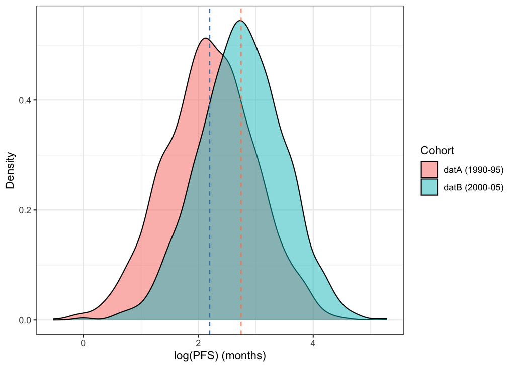

Figure A6. Distribution of log(PFS) in datA vs datB.

```r
bind_rows(
  datA |> select(log_PFS) |> mutate(Cohort = "datA (1990-95)"),
  datB |> select(log_PFS) |> mutate(Cohort = "datB (2000-05)")
) |>
  ggplot(aes(x = log_PFS, fill = Cohort)) +
  geom_density(alpha = 0.5) +
  geom_vline(xintercept = c(mean(datA$log_PFS), mean(datB$log_PFS)),
             linetype = "dashed", color = c("steelblue", "coral")) +
  labs(x = "log(PFS) (months)", y = "Density") +
  theme_bw()
```